# Sentiment analysis with tidy data

## 1.4 Most common positive and negative words

감정과 단어가 모두 포함된 데이터 프레임이 가지는 이점으로는 각 감정에 기여하는 단어 수를 분석할 수 있다는 것이다. 아래에는 ’word’와 ’sentiment’를 인수로 `count()`를 사용하면 각 단어가 각 감정에 얼마나 기여했는지를 알 수 있다.

```r
bing_word_counts <- tidy_books %>%
  inner_join(get_sentiments("bing")) %>%
  count(word, sentiment, sort = TRUE) %>%
  ungroup()
bing_word_counts
```

```
## # A tibble: 2,585 x 3
##    word     sentiment     n
##    <chr>    <chr>     <int>
##  1 miss     negative   1855
##  2 well     positive   1523
##  3 good     positive   1380
##  4 great    positive    981
##  5 like     positive    725
##  6 better   positive    639
##  7 enough   positive    613
##  8 happy    positive    534
##  9 love     positive    495
## 10 pleasure positive    462
## # ... with 2,575 more rows
```

이 데이터는 파이프 연산자를 사용하여 바로 ggplot2와 연결하여 시각화 할 수 있다.

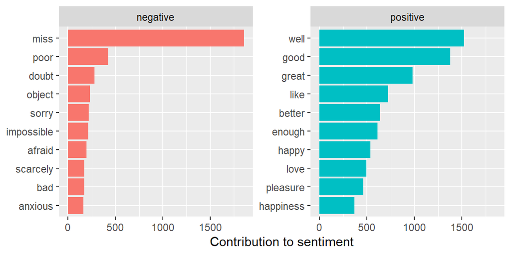

Words that contribute to positive and negative sentiment in Jane Austen’s novels

```r
bing_word_counts %>%
  group_by(sentiment) %>%
  slice_max(n, n = 10) %>%
  ungroup() %>%
  mutate(word = reorder(word, n)) %>%
  ggplot(aes(n, word, fill = sentiment)) +
  geom_col(show.legend = FALSE) +
  facet_wrap(~sentiment, scales = "free_y") +
  labs(x = "Contribution to sentiment",
       y = NULL)
```

그림 2.4를 사용하면 감정 분석에서 이상한 점을 확인 할 수 있다. “miss”라는 단어는 부정적인 의미로 어휘집에 들어가 있지만 제인 오스틴의 작품에서 젊은 미혼 여성을 칭하는 단어로 쓰이기도 한다. 따라서 이런 경우와 같이 감정 평가에 사용할 수 없는 불용어와 같은 단어라면 불용어 목록에 포함시킬 수 있다.

```r
custom_stop_words <- bind_rows(tibble(word = c("miss"),
                                      lexicon = c("custom")),
                               stop_words)

custom_stop_words
```

```
## # A tibble: 1,150 x 2
##    word        lexicon
##    <chr>       <chr>
##  1 miss        custom
##  2 a           SMART
##  3 a's         SMART
##  4 able        SMART
##  5 about       SMART
##  6 above       SMART
##  7 according   SMART
##  8 accordingly SMART
##  9 across      SMART
## 10 actually    SMART
## # ... with 1,140 more rows
```

## 1.5 Wordclouds

tidy text mining을 사용하면 ggplot2에서 잘 작동하지만 다른 플롯을 그릴 때도 유용하다.

예를 들어 기본 R그래픽을 사용하는 `wordcloud`package를 고려할 수 있다. 제인 오스틴의 작품 전체에서 가장 흔한 단어를 그림 2.5를 통해 확인했지만 이번에는 Word Cloud를 사용해서 확인해 본다.

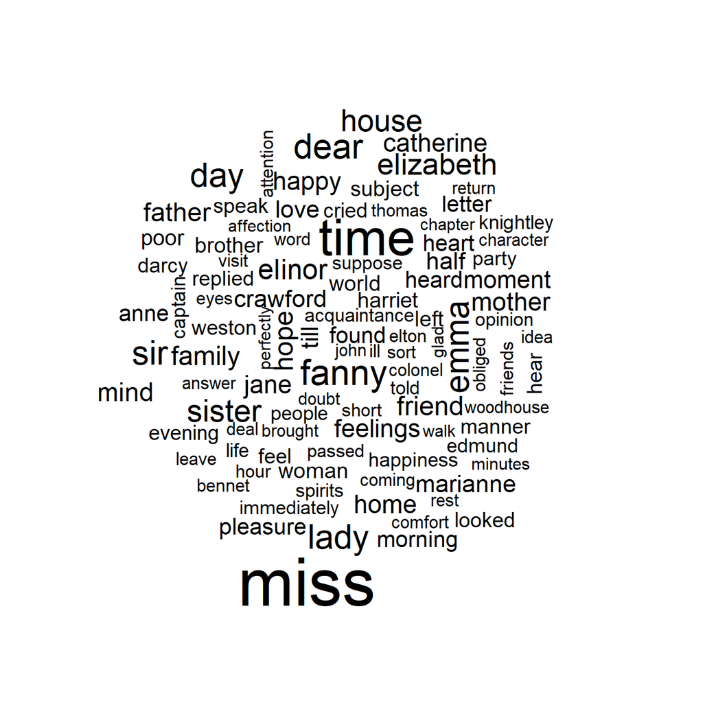

The most common words in Jane Austen’s novels

```r
library(wordcloud)
tidy_books %>%
  anti_join(stop_words) %>%
  count(word) %>%
  with(wordcloud(word, n, max.words = 100))
```

`comparison.cloud()`와 같은 다른 함수를 사용하려면 `reshape2`package의 `acast()`를 사용하여 데이터 프레임을 행렬로 변환해야 한다. `inner_join()`을 사용하여 단어에 해당하는 감정(positive 혹은 negative)을 추가하고 `count()`를 사용하여 각 단어가 몇 번씩 나왔는지 정렬한다. 그 다음 `acast()`로 데이터 프레임을 매트릭스 형식으로 변경 후 `comparison.cloud()`를 사용하여 시각화 한다.

```r
library(reshape2)
```

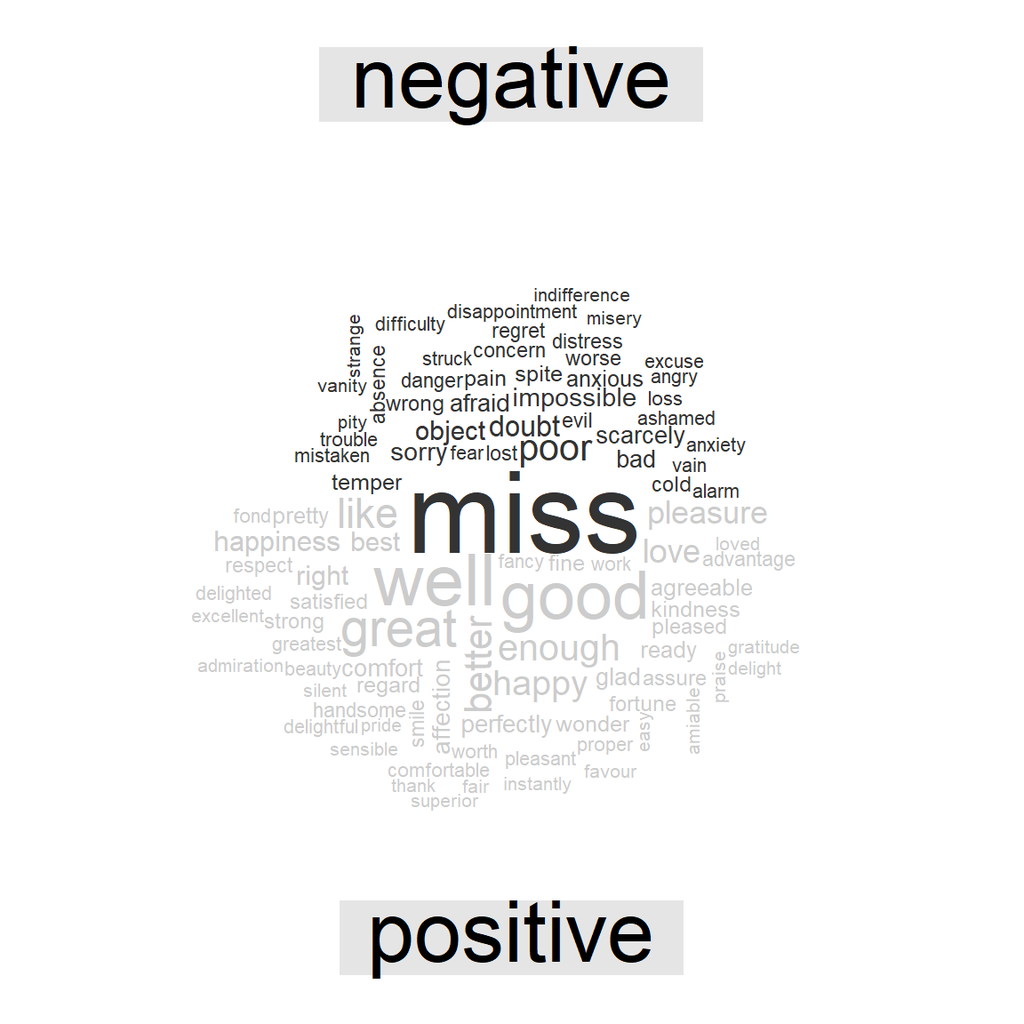

Most common positive and negative words in Jane Austen’s novels

```r
tidy_books %>%
  inner_join(get_sentiments("bing")) %>%
  count(word, sentiment, sort = TRUE) %>%
  acast(word ~ sentiment, value.var = "n", fill = 0) %>%
  comparison.cloud(colors = c("gray20", "gray80"),
                   max.words = 100)
```

그림 2.6에서 단어 크기는 빈도 수에 비례한다. 이 시각화를 사용하여 가장 중요한 긍정적인 단어와 부정적인 단어를 확인할 수 있지만 감정 간의 단어 크기는 비교할 수 없다.

## 1.6 Looking at units beyond just words

단어 수준에서 토큰화하여 많은 유용한 작업을 수행할 수 있지만 다른 텍스트 단위로 분석을 수행하는 것이 필요한 경우도 있다. 예를 들어 일부 감정 분석 알고리즘은 문장 전체의 감정을 이해하기 위해 유니그램(단일단어)이상을 분석한다. 이 알고리즘을 이용하면 아래 문장이 부정문임을 알고 좋은 날이 아니라는 것으로 이해한다.

> I am not having a good day.

`coreNLP`package, `cleanNLP`package, `sentimentr`package등의 R package는 이러한 감정분석 알고리즘의 예이다. 이를 위해 텍스트를 문장으로 토큰화 할 수 있으며 이러한 경우 출력 열에 새로운 이름을 사용하는 것이 좋다.

```r
p_and_p_sentences <- tibble(text = prideprejudice) %>%
  unnest_tokens(sentence, text, token = "sentences")
```

Let’s look at just one.

```r
p_and_p_sentences$sentence[2]
```

```
## [1] "by jane austen"
```

문장 토큰화는 UTF-8으로 인코딩된 텍스트, 특히 대화를 나타내는 부분에서 약간 문제가 있어 보인다. ASCII 구두점을 사용하면 훨씬 나은데 토큰화를 하기 전에 `mutate()`에서 `iconv(text, to = 'latin1')`과 같은 형태로 `iconv()`를 사용하는 것이 좋다. `iconv()`는 인코딩간 문자 벡터를 변환해주는 함수이다.

`unnest_tokens()`의 또 다른 옵션은 정규식패턴(regex)을 사용하여 토큰으로 분할하는 것이다. 예를 들어 정규식 패턴을 사용하여 소설 내용을 챕터 별로 데이터 프레임 형식으로 나눌 수 있다.

```r
austen_chapters <- austen_books() %>%
  group_by(book) %>%
  unnest_tokens(chapter, text, token = "regex",
                pattern = "Chapter|CHAPTER [\\dIVXLC]") %>%
  ungroup()

austen_chapters %>%
  group_by(book) %>%
  summarise(chapters = n())
```

```
## # A tibble: 6 x 2
##   book                chapters
##   <fct>                  <int>
## 1 Sense & Sensibility       51
## 2 Pride & Prejudice         62
## 3 Mansfield Park            49
## 4 Emma                      56
## 5 Northanger Abbey          32
## 6 Persuasion                25
```

각 소설의 챕터 수를 구해봤다. (각 소설 제목에 대한 행도 포함되어 있다.) 예를 들어 ‘austen_chapters’ 데이터 프레임에서 각 행은 하나의 챕터에 해당한다.

이 장의 시작 부분에서 유사하게 정규표현식을 사용하여 한 행에 한 단어씩 들어간 tidy format의 데이터 프레임에 대해 오스틴의 소설에서 챕터가 어디에 있는지 찾았다. tidy text 분석을 사용해서 소설에서 가장 부정적인 챕터가 어디인지 찾을 수 있다. 이를 위해 먼저 bing 사전에서 부정적인 단어 목록을 가져온다.

다음으로 각 챕터의 길이를 정규할 할 수 있도록 각 챕터의 단어수를 데이터 프레임으로 만든다.

마지막으로 각 챕터에서 부정적인 의미를 가진 단어를 구하고 각 챕터의 총 단어수로 나눈다. 그러면 부정적인 단어의 비율이 가장 높은 챕터를 찾을 수 있다.

```r
bingnegative <- get_sentiments("bing") %>%
  filter(sentiment == "negative")

wordcounts <- tidy_books %>%
  group_by(book, chapter) %>%
  summarize(words = n())
tidy_books %>%
  semi_join(bingnegative) %>%
  group_by(book, chapter) %>%
  summarize(negativewords = n()) %>%
  left_join(wordcounts, by = c("book", "chapter")) %>%
  mutate(ratio = negativewords/words) %>%
  filter(chapter != 0) %>%
  slice_max(ratio, n = 1) %>%
  ungroup()
```

```
## # A tibble: 6 x 5
##   book                chapter negativewords words  ratio
##   <fct>                 <int>         <int> <int>  <dbl>
## 1 Sense & Sensibility      43           161  3405 0.0473
## 2 Pride & Prejudice        34           111  2104 0.0528
## 3 Mansfield Park           46           173  3685 0.0469
## 4 Emma                     15           151  3340 0.0452
## 5 Northanger Abbey         21           149  2982 0.0500
## 6 Persuasion                4            62  1807 0.0343
```

각 책에서 가장 슬픈 단어가 포함된 챕터는 부정적인 단어 대비 총 단어수의 비율로 정규화되어 나타난다. *Sense and Sensibility*의 43장에서 Marianne은 중병에 걸려 죽음을 눈앞에 두고 있으며, *오만과 편견*의 34장에서 Mr. Darcy는 처음으로 프러포즈한다. *맨스필드 파크*의 46장 모든 사람들이 헨리의 추악한 간통에 대해 알게 되면서 거의 끝나가고 있으며, *엠마*의 15장은 무시무시한 엘튼 씨가 청혼할 때이며, *노생거 수도원*의 21장에서 캐서린은 살인의 환상에 빠져있고 *설득*의 4장은 독자가 앤이 웬트워스 대위를 거부하고 그녀가 얼마나 슬펐고 그녀가 그것을 깨달았는지 얼마나 끔찍한 실수인지에 대한 완전한 회상을 하는 때이다.

## 1.7 Summary

감정 분석은 텍스트에 표현된 태도와 의견을 이해하는 방법을 제공한다. 이번 장에서 tidy data 원칙을 사용하여 감정분석을 하는 방법을 배웠다. 텍스트 데이터가 깔끔한 구조일 때 감정 분석을 `inner_join()`으로 구현할 수 있음을 확인했고, 감정 분석을 사용하여 전체 줄거리가 어떻게 변하는지를 시각화 할 수 있었다.